# s07 — structural variants as a confounder (chr19; the hard limit)

gwct

10/26/2026 13:04 EDT

```r
knitr::opts_chunk$set(echo = TRUE, warning = FALSE, message = FALSE, fig.align = "center")
library(ggplot2); library(dplyr); library(tidyr); library(readr)
source("analyses/lib/design.r")   # bartheme(), corecol(); knit from the project root
```

**Provenance**

- **Rendered from commit** `761a36dcb53d` (branch `mason2-sims`) on 2026-10-26 13:04
- **This notebook:** notebook as committed
- **Analysis code:** no uncommitted edits under `analyses/`
- Each data file’s producing script and command: the section’s `MANIFEST.yaml`

# 1 Question & design

**Structural variants are where the whole framework breaks.** Everything up to here treated reference bias as a function of *divergence* — how different the sample is, base for base. An SV is not that: a deletion removes reference-orthologous sequence, an insertion adds sequence with no reference home. It is **unmappability**, not high local divergence, so the separable divergence model (s05) does not describe it.

And there are two hard facts:

- **Our callers cannot call SVs.** gatk / bcftools / freebayes are small-variant callers; they do not emit large deletions/insertions. So SVs are a **~100 % blind spot**, and because iteration only bakes in what gets *called*, iteration cannot recover them either.
- **SVs still wreck the neighborhood.** Reads spanning a breakpoint clip or fail to map, so *small-variant* recovery collapses locally around every SV.

This section measures SVs purely **as a confounder of small-variant calling** (recovering the SVs themselves would need dedicated SV callers + SV-aware scoring — out of scope).

- **Setup.** 1000 homozygous SVs (~500 deletions + ~500 insertions, 50–5000 bp, uniform; insertions get random novel sequence) placed in the truth alongside a **low SNP+indel background (D = 0.02)** — low on purpose, so baseline small-variant recovery is high (~99 %) and the SV footprint stands out. Simulated (`mason`), mapped (`bwa`), called by all three callers, iterated with the s02 indel+liftover pipeline (`workflow.smk`, `config-sv.yaml`). chr19, 30×, seed 42.
- **Measurement** (`scripts/sv_confounder.py`): every divergent SNP/indel truth site is binned by its **distance to the nearest SV breakpoint** (deletions contribute both junctions, insertions their anchor), and we score recovery (matched to the accumulated recovered set) per caller × iteration. The far bin (> 5 kb) is the SV-free baseline.

```r
sv <- read_csv("analyses/s07-svs/results/s07-sv-confounder.csv") %>%
  mutate(caller = factor(caller, levels = c("gatk", "bcftools", "freebayes")),
         iteration = factor(iteration),
         dist_mid = as.numeric(dist_mid))
fp <- read_csv("analyses/s07-svs/results/s07-sv-confounder-fp.csv") %>%
  mutate(caller = factor(caller, levels = c("gatk", "bcftools", "freebayes")))
cols_it <- corecol(pal = "wilke", numcol = 3)
```

# 2 The SV footprint on small-variant recovery

SNP recovery against distance from the nearest SV breakpoint (log scale; the rightmost point is the > 5 kb baseline). Every caller has a hole at the breakpoint that heals within ~one read length — but the **depth of the hole is a caller property**.

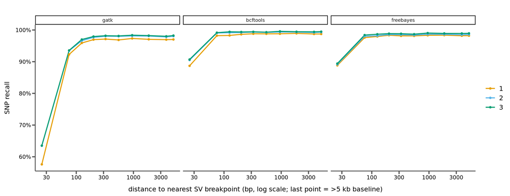

```r
d <- sv %>% filter(vtype == "snp", bptype == "any")
ggplot(d, aes(dist_mid, recall, color = iteration)) +
  geom_line(linewidth = 0.9) + geom_point(size = 1.4) +
  scale_x_log10() +
  scale_color_manual(values = cols_it, name = "iteration") +
  scale_y_continuous(labels = scales::percent) +
  facet_wrap(~caller, nrow = 1) +
  labs(x = "distance to nearest SV breakpoint (bp, log scale; last point = >5 kb baseline)",
       y = "SNP recall") +
  bartheme() + theme(legend.position = "right")
```

*Interpretation.*

- **The pileup callers lose ~10 points** at the breakpoint (bcftools/freebayes 0.89 vs ~0.98 baseline, 0–50 bp) and heal by ~100 bp — only the reads that span the junction clip; the clean flanking reads still call the nearby SNP.
- **gatk loses ~40 points** (0.58 vs 0.97 baseline). Its reassembler is confounded by the clipped/chimeric reads at the junction and fails to assemble the local haplotype — the same calling-limited vulnerability seen throughout (s05), now triggered by SV breakpoints rather than divergence.
- **Iteration lifts the neighborhood but cannot close the breakpoint.** From iteration 1 → 3 the hole shrinks a little (gatk 0.58 → 0.64 at 0–50 bp) but a large residual remains, because the SV is never called, never baked into the consensus, so breakpoint-spanning reads keep clipping at every iteration. The dropout right at the junction is permanent.

## 2.1 Deletions vs. insertions

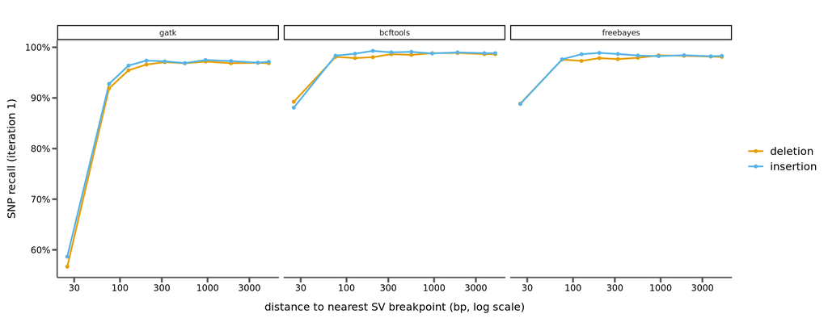

```r
di <- sv %>% filter(vtype == "snp", bptype %in% c("del", "ins"), iteration == "1")
ggplot(di, aes(dist_mid, recall, color = bptype)) +
  geom_line(linewidth = 0.9) + geom_point(size = 1.4) +
  scale_x_log10() +
  scale_color_manual(values = corecol(pal = "wilke", numcol = 2),
                     name = NULL, labels = c(del = "deletion", ins = "insertion")) +
  scale_y_continuous(labels = scales::percent) +
  facet_wrap(~caller, nrow = 1) +
  labs(x = "distance to nearest SV breakpoint (bp, log scale)", y = "SNP recall (iteration 1)") +
  bartheme() + theme(legend.position = "right")
```

# 3 SVs also create false positives near breakpoints

The other side of the confounder: clipped/chimeric reads at breakpoints don’t just lose true calls, they spawn false ones. Enrichment = the fraction of a caller’s single-shot false positives within 150 bp of a breakpoint, divided by the genomic fraction that close (0.74 %).

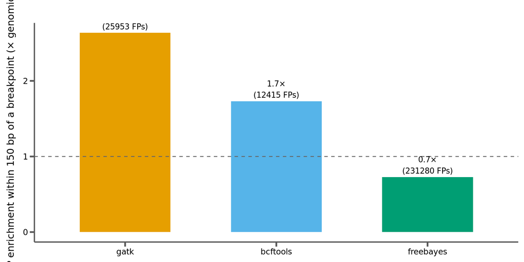

```r
ggplot(fp, aes(caller, enrichment, fill = caller)) +
  geom_col(width = 0.6) +
  geom_hline(yintercept = 1, linetype = "dashed", color = "grey40") +
  geom_text(aes(label = sprintf("%.1f×\n(%d FPs)", enrichment, n_fp)), vjust = -0.2, size = 3.4) +
  scale_fill_manual(values = corecol(pal = "wilke", numcol = 3), guide = "none") +
  labs(x = NULL, y = "FP enrichment within 150 bp of a breakpoint (× genomic)") +
  bartheme()
```

*Interpretation.* **gatk (2.6×) and bcftools (1.7×) concentrate false positives at breakpoints** — the chimeric reads there generate spurious calls. **freebayes is the exception (0.7×)** not because it’s clean but the opposite: it emits so many false positives *everywhere* (231 k, its complex/multiallelic floor from s02) that breakpoints don’t stand out. So SVs degrade precision locally for the disciplined callers, and freebayes’ FP problem swamps the signal.

# 4 The blind spot

Of the **1000 SVs**, the number recovered by small-variant calling + iteration is **0** (bcftools, gatk) or **1** (freebayes, an incidental large complex call — not systematic SV recovery). SVs are, by construction, invisible to this pipeline: the callers can’t emit them and iteration can’t bake in what was never called. This is the permanent blind spot — no amount of divergence-recovery machinery touches it.

# 5 Summary

- **SVs are off the divergence axis.** They are unmappability, not high local divergence, so the separable model (s05) does not describe them — this is where the framework stops.
- **A sharp local footprint on small-variant recovery.** SNP recovery craters within ~50 bp of a breakpoint and heals by ~100 bp. The depth is caller-specific: **pileup callers −10 pt, gatk −40 pt** (its reassembler fails on the junction reads — the calling-limited mechanism again).
- **Iteration can’t close it.** It lifts the neighborhood slightly but the breakpoint dropout is permanent, because the SV is never called and so never enters the consensus.
- **Precision suffers too.** False positives are enriched 1.7–2.6× at breakpoints for the disciplined callers (freebayes’ baseline FP flood hides it).
- **The SVs themselves are a ~100 % blind spot.** Small-variant calling + iteration recover essentially none of them.
- **Bottom line — the hard limit.** Reference bias from SNPs and indels is a recall problem that mapping quality and iteration can push back on. SVs are a different failure mode: a permanent, local blind spot that iterative small-variant calling cannot address, only avoid. Recovering them needs dedicated SV callers — a separate problem.

*Data tables + dictionaries: `results/s07-sv-confounder.csv` (recovery vs distance) and `results/s07-sv-confounder-fp.csv` (FP enrichment). SVs on a D = 0.02 background, single seed 42.*